# Praca domowa 4

Damian Gutowski

7 listopada 2018

## Źródło danych

Jako dane wybrałem informacje o kredytach konsumenckiich udzielanych przez 8 banków działających w Polsce. Oryginalny wykres znajduje się pod adresem: https://github.com/pbiecek/TechnikiWizualizacjiDanych2018/blob/master/PraceDomowe/PD1/TWDWachulec1.html

## A) wykres czarnobiały

Ponieważ na wykresie przedstawionio kolorami różne zmienne, należy wybrać, między przygotowaniem kilku wykresów, przygotowaniem jednego wykresu z zamieniem kolorów na odcienie szarości, lub zmniejszenie liczby zmiennych.  
Pierwszy wybór nie jest najlepszy, gdyż prosta zmiana koloróW na skalę szarości spowoduje wielkie trudności z odczytaniem, który słupek odpowada której zmiennej. Nie zdecydowałem się również przygotowanie 4 wykresów, gdyż moim zadaniem była prosta wizualizacja danych, a nie tworzenie wnikliwej analizy. Aby zachować czytelność wykresu przedstawiłem tylko najważniejszy czynnik czyli całkowity koszt kredytu poniesiony przez konsumenta.

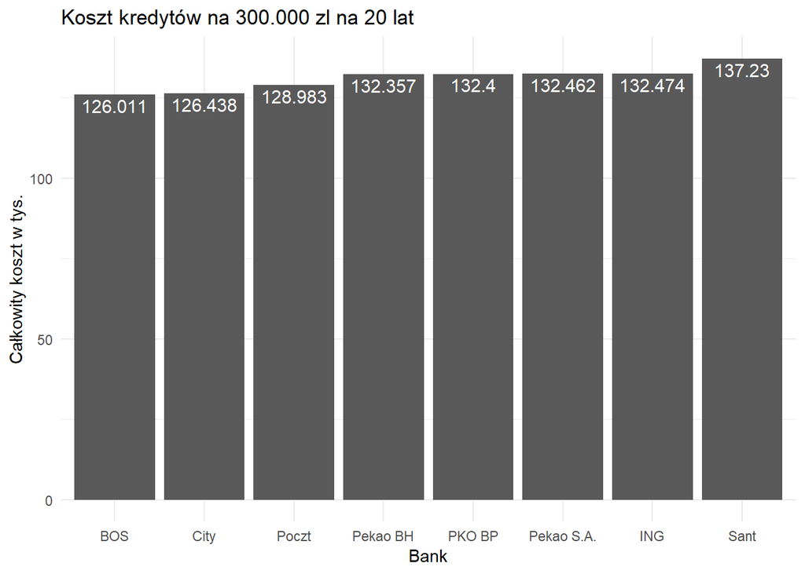

```r
dt1 <- dt[,c(1,2)]
dt1[,2] <-dt1[,2] / 1000

ggplot(dt1, aes(x=Bank, y=Koszt)) +
  geom_bar(stat="identity") +
  geom_text(aes(label = Koszt), vjust=1.3, color="white", size=4) +
  labs(y = "Całkowity koszt w tys.", title="Koszt kredytów na 300.000 zl na 20 lat") +
  theme_minimal()
```

## B) Wykres kolorowy

```r
dt2 <- dt[, -c(6,2)]
dt2 <- melt(dt2)
```

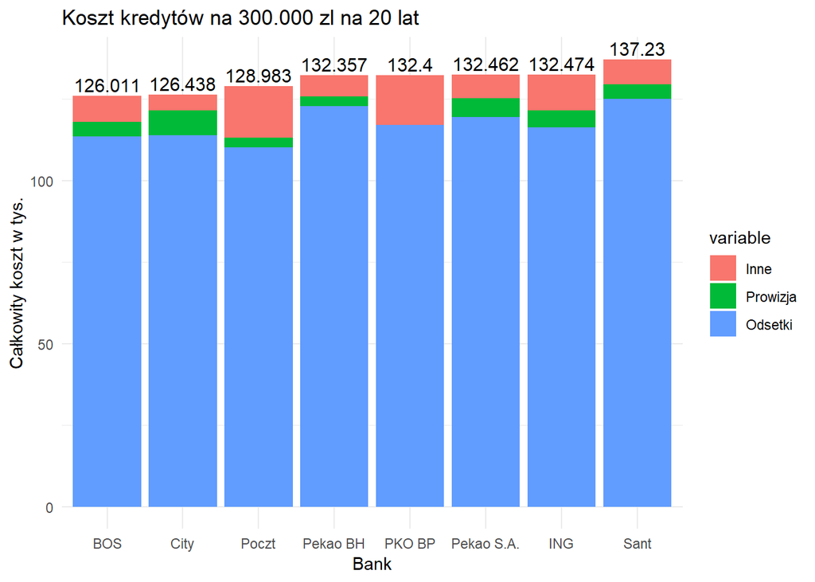

```r
dt2[,3] <- dt2[,3] / 1000
dt2$label <- dt1$Koszt
dt2[1:16,4] <- ""

ggplot(dt2, aes(x=Bank, y=value, fill=variable)) +
  geom_bar(stat="identity") +
  geom_text(aes(label = label, y = as.numeric(dt2[,4])),vjust=-0.3, color="black", size=4) +
  labs(y = "Całkowity koszt w tys.", title="Koszt kredytów na 300.000 zl na 20 lat") +
  theme_minimal()
```